# APA figures in ggplot

Tehran Davis

11/4/2017

Hi all, a few of you have asked for something a little more concrete with respect to producing APA tables and figures in R. So far, I’ve simply stated that if you use my templates, you will be fine for the course. Here I’m going to show you how I derived my templates, with the hope that this may serve as a useful springboard for any adjustments you choose to make in the future. As an example we will be using the Eysenck data from Howell 13.1: Factorial ANOVA designs.

```r
# check to make your computer has pacman installed, if not install
if (!require(pacman)){install.packages('pacman')}
```

```r
# use pacman to check, install, and load necessary packages
pacman::p_load(devtools, dplyr, ggplot2, pander, knitr, kableExtra, plyr, psych)
```

```r
dataset <- read.table("https://www.uvm.edu/~dhowell/methods8/DataFiles/Tab13-2.dat", header = T)

# label dummy codes:
dataset$Age <- plyr::mapvalues(dataset$Age,from = c(1,2), to = c("Old","Young")) %>% as.factor()

dataset$Condition <- plyr::mapvalues(dataset$Condition,from = c(1,2,3,4,5), to = c("Counting","Rhyming","Adjective","Imagery","Intentional")) %>% as.factor()

summary(dataset)
```

```
##     Age           Condition      Recall
##  Old  :50   Adjective  :20   Min.   : 3.00
##  Young:50   Counting   :20   1st Qu.: 7.00
##             Imagery    :20   Median :11.00
##             Intentional:20   Mean   :11.61
##             Rhyming    :20   3rd Qu.:15.25
##                              Max.   :23.00
```

# Building a figure:

There are other tutorials where I’ve run, step-by-step with how to construct a plot in `ggplot2` and many other more comprehensive tutorials online. BUT for the purpose of showing you how I go about generating an APA-friendly plot, let’s walk through the steps again.

First, let’s construct a baseline plot using `ggplot2`. Given that I have two IVs, I need to decide the appropriate layout. Typically, this means that I need to put one IV along the `x`-axis, and `group` the other IV by shape, color, location, or linetype depending on what type of plot I choose to run. Note that if I only have 1 IV I typically place it on the x-axis, an no need to worry about grouping.

## Generating a Line plot (general)

Code for baseline:

```r
# setting up ggplot
require(ggplot2)

# place "Condition" on x-axis
# place "Recall" on y-axis
# group "Age"

p <- ggplot(data=dataset,mapping = aes(x=Condition,y=Recall,group=Age))
```

For here we can make several choices on how we want to proceed. Typically when we are plotting data that compares means between groups, we use a means plot—this usually takes the form of a barplot, lineplot, or boxplot. Each of these can be called using combinations of the `ggplot2::stat_summary()` command and adding it to our baseline plot. There are several major components to the `stat_summary()` command:

- function to be applied via `fun.y` or `fun.data` –`fun.y` defines what values your plot takes along the `y-axis`. For example calling the `mean()` function via `fun.y = mean` says that the plotted values should represent the mean. –`fun.data` is used for getting other data values in addition to mean, like calculating standard errors or confidence intervals. For example `fun.data=mean_se` tells `ggplot2` to create a location that conveys info about the mean and standard error. Alternative values include `mean_cl_normal` which can be used to get confidence intervals. To get a feel for what is happening here, let’s try typing the following into our console:

```r
mean(dataset$Recall) # gives us mean only
```

```
## [1] 11.61
```

```r
mean_se(dataset$Recall) # gives us mean, and SE (ymin, ymax)
```

```
##       y     ymin     ymax
## 1 11.61 11.09089 12.12911
```

```r
mean_cl_normal(dataset$Recall) # gives us mean, and 95% CI (ymin, ymax)
```

```
##       y     ymin     ymax
## 1 11.61 10.57998 12.64002
```

- `geom` tells us what kind of plot. – `point`: point plot – `pointrange`: point with lines conveying error bars (if using points I’d suggest this) – `line`: adds lines (and only lines, usually needs to be used in combination with `point` or `pointrange`) – `bar`: for barplot – `errorbar`: generates error bars (best used with `bar`) – `boxplot`: generates boxplots (note line is median)
- parameters like `size`, `color`, `position` and `linetype` control the appearance of the object. Use them outside of the `aes()` mapping and use specific values to impact the entire `geom()`. Values that can be however…
- `aes()`, aesthetics: calling `shape`, `color`, or `linetype` within `aes()` mapping is interpreted as “change according to this factor”. Typically this should factor needs to be include in your `group` call from the baseline plot. For example `aes(shape=Age)` is interpreted as “each level in the `Age` factor gets a different shape”.

As we’ve discussed before, you can think of a `ggplot` as adding a new layer onto the plot with each line. So..

Let’s draw some points for each of the means. Again, our baseline:

```r
p <- ggplot(data=dataset,mapping = aes(x=Condition,y=Recall,group=Age))
```

And now to add points with standard error bars at each of the means:

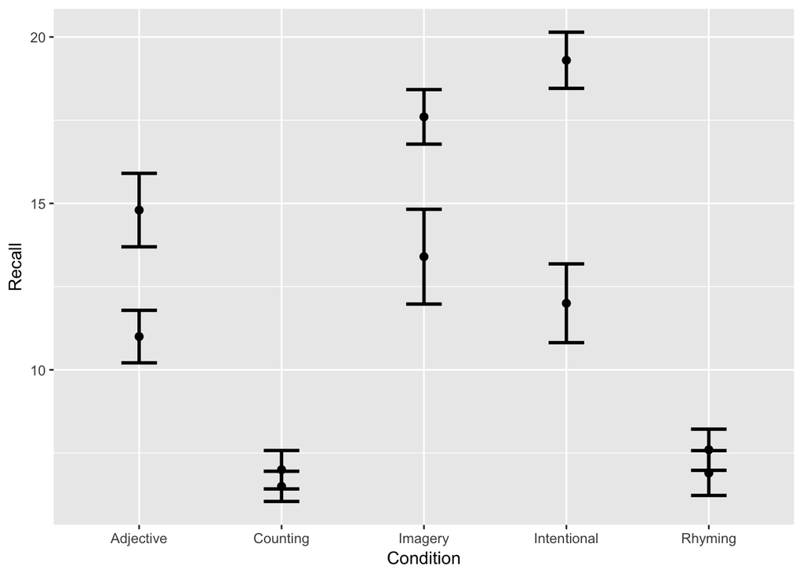

```r
# adding points, size 2, color black
p <- p + stat_summary(fun.y = mean, size=2, color="black", geom="point")

# adding errorbars to the above, size = line thickness, width = width of whiskers
p <- p + stat_summary(fun.data = mean_se, size=1, width= 0.25, color="black", geom="errorbar")
show(p)
```

or I could just kill two birds with one stone using `geom=pointrange` instead (also from here on out I’m coding more efficiently when possible, limiting redundant `p <-` when possible):

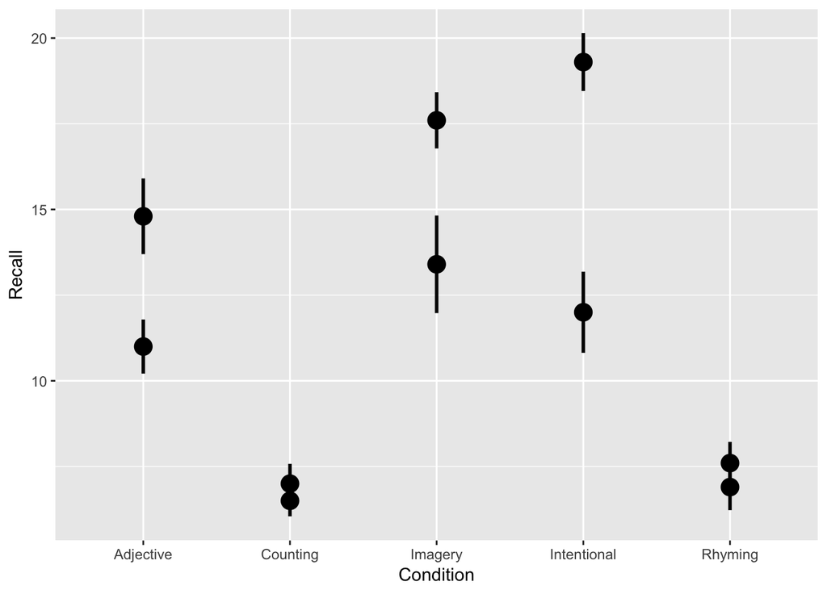

```r
# plus at the end says continue to next line before executing
p <- ggplot(data=dataset,mapping = aes(x=Condition,y=Recall,group=Age)) +
  # adding pointrange that includes point for mean and SE lines
  stat_summary(fun.data = mean_se, size=1, color="black", geom="pointrange")
show(p)
```

OK. A few things stick out. First, there is no differentiation here—both age groups are represented by circles. Second, in some cases the circles overlap with one another, making it a little more difficult to interpret. To deal with these issues we can call on the `aes()` and `position` parameters. In `aes()` we are going to tell ggplot to use different shapes for each `Age` group. In `position` we are going to create a dodge where there is no overlap as each point is moved in slightly opposite directions. Again, starting with our baseline:

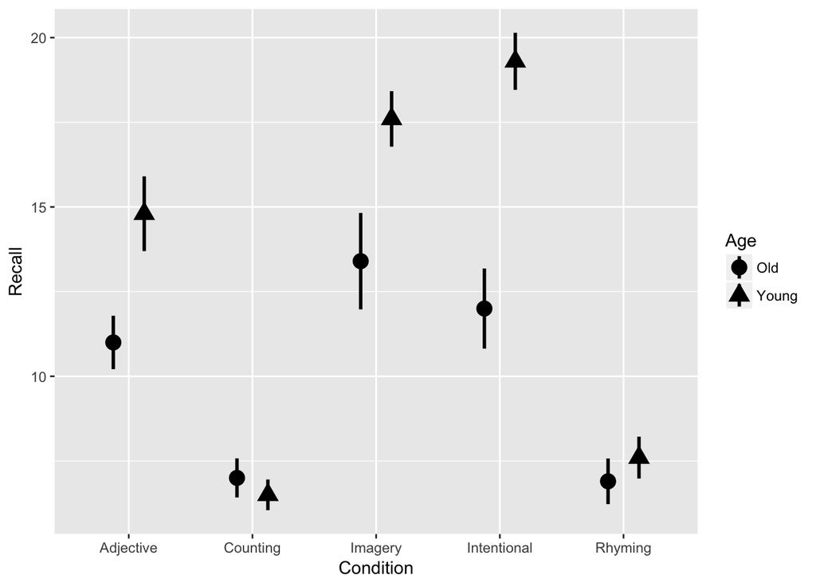

```r
p <- ggplot(data=dataset,mapping = aes(x=Condition,y=Recall,group=Age)) +
  # adding aes(shape=Age) and position=position_dodge()
  stat_summary(fun.data = mean_se, size=1, color="black", geom="pointrange", position = position_dodge(.5), aes(shape=Age))
show(p)
```

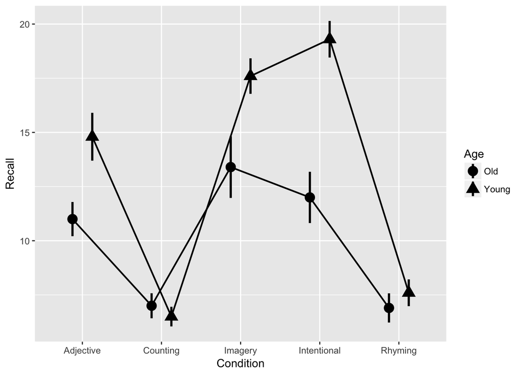

```r
p <- ggplot(data=dataset,mapping = aes(x=Condition,y=Recall,group=Age)) +
  stat_summary(fun.data = mean_se, size=1, color="black", geom="pointrange", position = position_dodge(.5), aes(shape=Age)) +
  # adding lines that connect at the mean; size = thickness of line
  stat_summary(fun.y = mean, size=0.75, color="black", geom="line", position = position_dodge(.5))
show(p)
```

Looking at this you may elect to do one last step with the data plotting provided your own preference. If for example you wanted one of your lines dashed you may rewrite last bit:

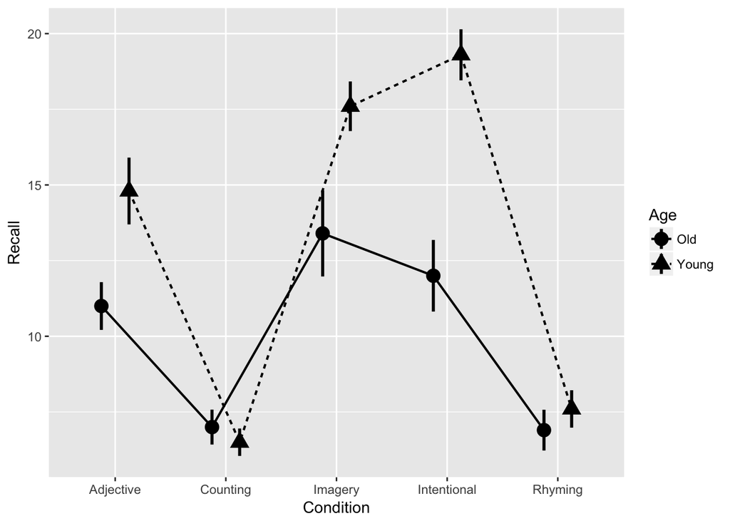

```r
p <- ggplot(data=dataset,mapping = aes(x=Condition,y=Recall,group=Age)) +
  stat_summary(fun.data = mean_se, size=1, color="black", geom="pointrange", position = position_dodge(.5), aes(shape=Age)) +
  # adding aes() changing linetype
  stat_summary(fun.y = mean, size=0.75, color="black", geom="line", position = position_dodge(.5), aes(linetype=Age))
show(p)
```

## Bar plot example

Alternatively I can generate different styles of plots using variations of above. For example, using what we have done, we can modify the code to create a barplot with standard error bars. In this case, instead of `Age` being conveyed by different shapes of linetypes, we can convey it by different color `fill` of each bar. Note that instead of specifying the size of `position_dodge()` we can also have `R` decide the optimal dodge by simple saying `position="dodge"`. Also note that this time around I’m going to make my error bars the 95% CI:

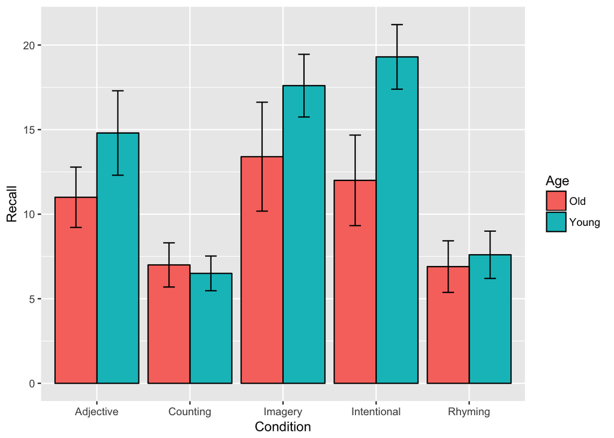

```r
p <- ggplot(data=dataset,mapping = aes(x=Condition,y=Recall,group=Age)) +
  # calling geom="bar" where top of bar is the mean; note that size and color here refer to bar's perimeter lines.
  stat_summary(fun.y = mean, size=.5, color="black", geom="bar", position = position_dodge(.9), aes(fill=Age)) +
  # adding 95% CI error bars:
  stat_summary(fun.data = mean_cl_normal, size=.5, width= 0.25, color="black", geom="errorbar", position = position_dodge(.9))
show(p)
```

## Box plot example

Boxplots are a little more complex as they require creating you own function to be called in `fun.data`. This function needs to define the `lower`, `middle`, and `upper` sections of the box (typically median and 25%-75% IQR), as well as the `ymin` and `ymax` limits of the whiskers (here I’ve chosen 95% CI: .025 and .975; rather than Tukey-style) and `outliers`. Here I’m building three functions. The first two `box_med` and `box-mean` set the line in the boxplot as either the median or mean (used interchangeably). The third, `box_out` may be used to add additional points representing outliers. Feel free to modify according to your own specifications.

```r
# Definition of whiskers
box_med <- function(x) {
  # define by quantiles where 50% is median:
  r <- quantile(x, probs = c(0.025, 0.25, 0.5, 0.75, 0.975))
  names(r) <- c("ymin", "lower", "middle", "upper", "ymax")
  r
}

box_mean <- function(x) {
  r <- quantile(x, probs = c(0.025, 0.25, 0.5, 0.75, 0.975))
  # replace median with mean
  r[3] <- mean(x)
  names(r) <- c("ymin", "lower", "middle", "upper", "ymax")
  r
}

# Add points outside of whiskers
box_out <- function(x) {
  subset(x, x < quantile(x,probs=0.025) | quantile(x,probs=0.975) < x)
}
```

Now onto the boxplot. I’m using the first stat_summary to create my box and whiskers; the second adds the outliers. Also, I’m using `aes(fill=Age)` for the boxplots and `aes(color=Age)` for the outlier points to add more contrast between the two Age groups:

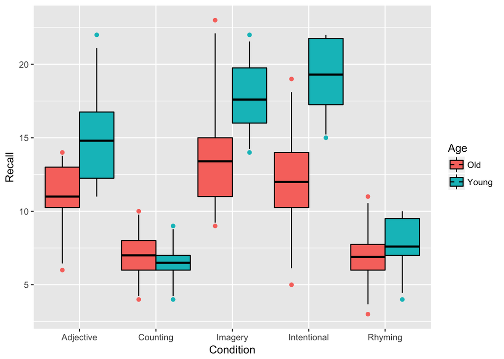

```r
p <- ggplot(data=dataset,mapping = aes(x=Condition,y=Recall,group=Age)) +
  # calling geom="baxplot"; using position to set grouped plots side-by-side
  stat_summary(fun.data = box_mean, size=.5, color="black", geom="boxplot", position=position_dodge(.9), aes(fill=Age)) +
  stat_summary(fun.y = box_out, geom="point", position=position_dodge(width=.9), aes(color=Age))
show(p)
```

# APA style prelims

Now that we have a baseline plot we can proceed to style it according to our standards. Here, I’m looking to guidelines from the APA 6th and well as Purdue OWL for inspiration. While the rules for generating an APA print-ready plot are notoriously vague, there are a few points of consensus:

- the plot should be minimalist, with a plain white background and no gridlines (or only use minimal gridlines when absolutely necessary).
- the plot should be in black, white, and (limited) grey-scale
- the plot font should be sans serif and at least 12pt (usually larger to make plot clearly legible).
- When necessary plot axes titles should contain units.
- The plot should NOT have a main title
- Any legends should be within the bounds of the plotting area, not off to one side.
- becoming more commonplace: plot axis titles should be in stronger/bolder font.

Provided these constraints there are two ways that we can turn our plot into an APA style plot.

# APA figures (from baseline to APA in 12*ish* lines of code)

## Working on a bar plot (general)

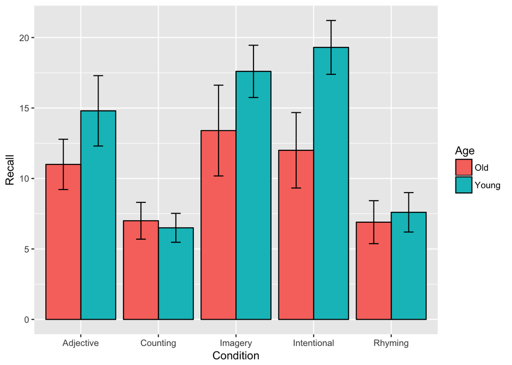

```r
p <- ggplot(data=dataset,mapping = aes(x=Condition,y=Recall,group=Age)) +
  # calling geom="bar" where top of bar is the mean; note that size and color here refer to bar's perimeter lines.
  stat_summary(fun.y = mean, size=.5, color="black", geom="bar", position = position_dodge(.9), aes(fill=Age)) +
  # adding 95% CI error bars:
  stat_summary(fun.data = mean_cl_normal, size=.5, width= 0.25, color="black", geom="errorbar", position = position_dodge(.9))
show(p)
```

From here we can make a myriad of customizations using calls within `ggplot2`. For extensive documentation, check [here](http://ggplot2.tidyverse.org/reference/theme.html).

First up, we need to remove the back panel, grid lines, and add axis lines. Using the documentation page referenced above, we see that this can be accomplished with the following:

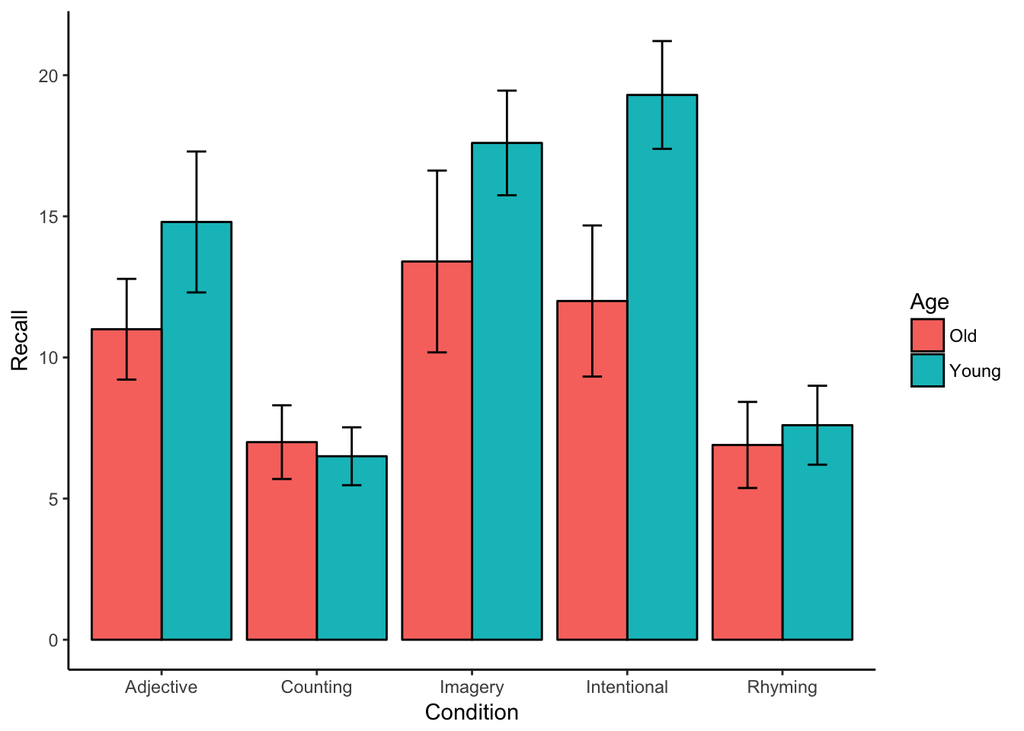

```r
p + theme(
  panel.background = element_rect(fill = "white", colour = NA),
  panel.border = element_blank(),
  panel.grid.major = element_blank(),
  panel.grid.minor = element_blank(),
  axis.line = element_line(colour = "black", size = 0.5),
  legend.key = element_blank(),
  strip.background = element_rect(fill = "white", colour = "black", size = 1),
  complete = TRUE)
```

Or a shortcut would be to call on `theme_classic()` or if you have cowplot `theme_cowplot()`. For this example I’ll be using `theme_classic()`

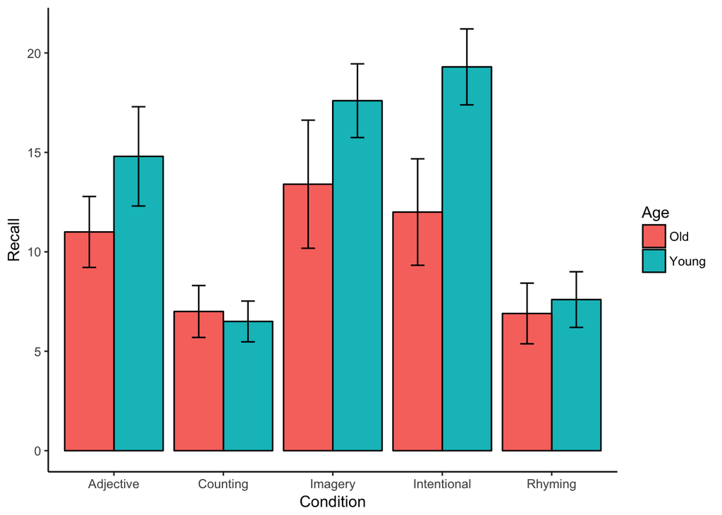

```r
p + theme_classic()
```

If your elect to use `theme_cowplot()`, you may notice that it adjusts our font sizes for us. This can be also accomplished by modifying the axis titles directly. We could also change our font family and face here with a little more precision. `R` typically defaults to san serif fonts, so here I’ll simply adjust my axis titles font size and face, as well as my legend title size and face. While I’m at it I’ll also adjust the size of the tick titles

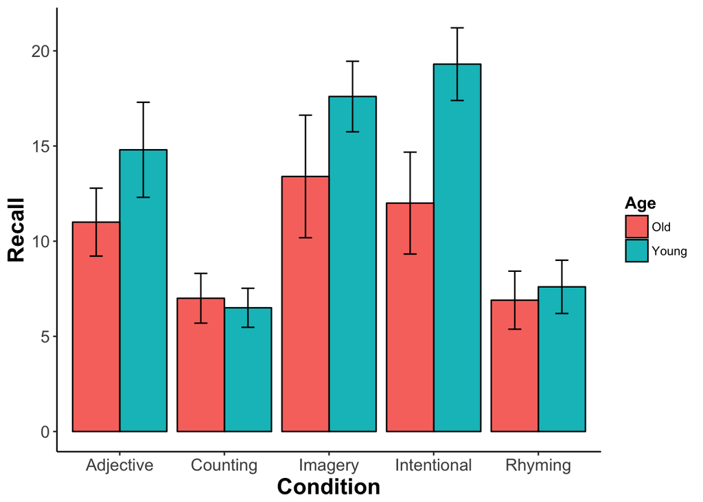

```r
p + theme_classic() + theme(
  axis.title = element_text(size = 16, face = "bold"),
  axis.text = element_text(size = 12),
  legend.title = element_text(size = 12, face = "bold"))
```

Further, APA demands that the legend be placed inside of the plotting area. Looking at this plot a good place to put it might be above the “Counting” condition. This can be accomplished by specifying the (x,y) position where we want our legend. Placing the legend involves imaging the plot to be a unit scale where (1,1) this the top right corner. Usually placing the legend requires a little trial and error:

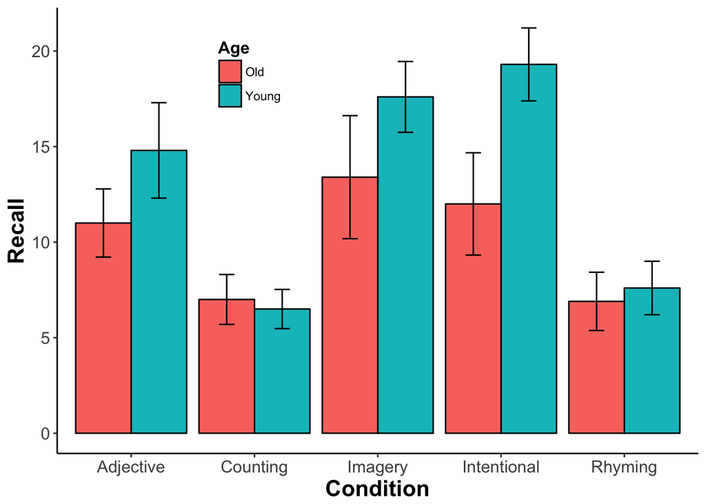

```r
p + theme_classic() + theme(
  axis.title = element_text(size = 16, face = "bold"),
  axis.text = element_text(size = 12),
  legend.title = element_text(size = 12, face = "bold"),

  #adding position:
  legend.position = c(.3,.85))
```

get everything in grey-scale (black, white, grey)

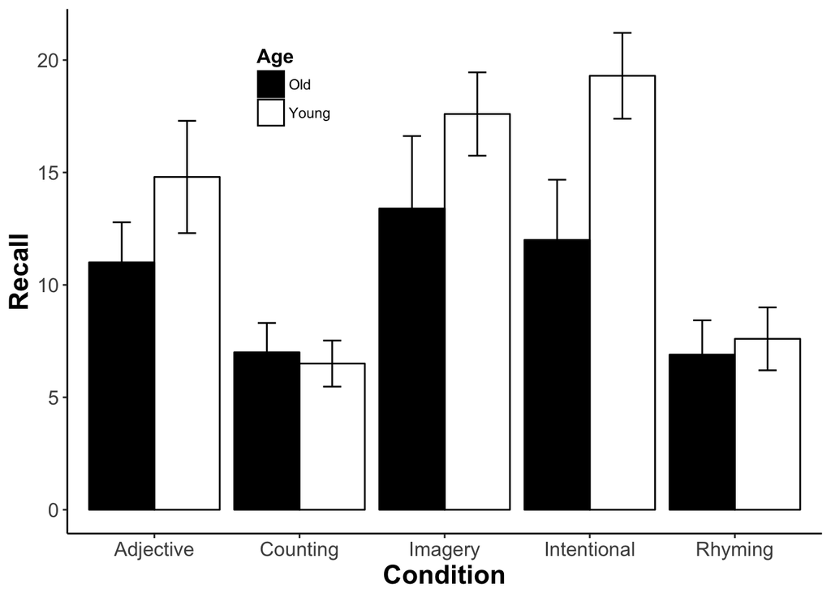

```r
p + theme_classic() + theme(
    axis.title = element_text(size = 16, face = "bold"),
    axis.text = element_text(size = 12),
    legend.title = element_text(size = 12, face = "bold"),
    legend.position = c(.3,.85)) +

  # black and white filled bars
  scale_fill_manual(values=c("black","white"))
```

note that I only need two colors here, but could add more as needed. See [here](https://www.nceas.ucsb.edu/~frazier/RSpatialGuides/colorPaletteCheatsheet.pdf) for a nice color cheat sheet.

Now to fix gap below y=0. This can be done by calling the scale_y_continuous function:

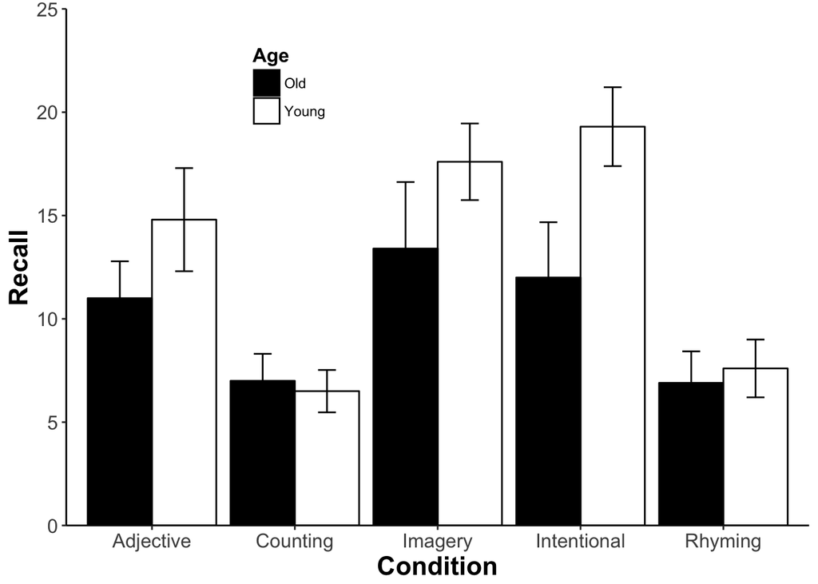

```r
p + theme_classic() + theme(
    axis.title = element_text(size = 16, face = "bold"),
    axis.text = element_text(size = 12),
    legend.title = element_text(size = 12, face = "bold"),
    legend.position = c(.3,.85)) +
  scale_fill_manual(values=c("black","white")) +

  # code to fix y-axis, set expand limits at desired min and max
  scale_y_continuous(expand = c(0,0)) + expand_limits(y=c(0,25))
```

Note that sometimes it’s not in you interest to start your y-axis at zero. This can be changed by calling the `coord_cartesian()` function, which performs a “zoom-in” on the plot. Note that this is entirely unnecessary in the present example, but I just want to show you anyway.

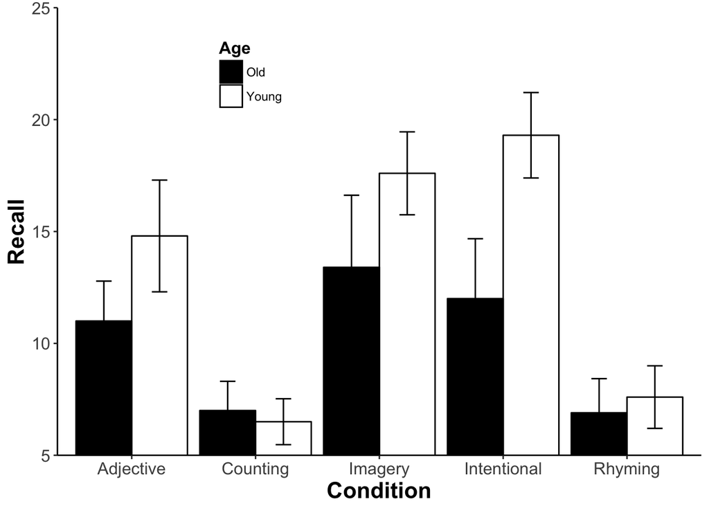

```r
p + theme_classic() + theme(
    axis.title = element_text(size = 16, face = "bold"),
    axis.text = element_text(size = 12),
    legend.title = element_text(size = 12, face = "bold"),
    legend.position = c(.3,.85)) +
  scale_fill_manual(values=c("black","white")) +
  scale_y_continuous(expand = c(0,0)) + expand_limits(y=c(0,25)) +

  # "zoom" plot into area capturing y=5 to y=25
  coord_cartesian(ylim = c(5,25))
```

Axes titles and level names default to those from the data frame. Typically the easiest way to change them is to rename them in the data frame itself. However, if you elect to change the axis title here (if, say for example you want to include parentheses, #, or other characters not allowed in data.frame headers) then you may call the `xlab()` and `ylab()` functions. One trick is to use “” to add a line of white space between the title and axis. Note that I’m also tweaking the `lineheight` parameter in `axis.title` to adjust the added blank line space.

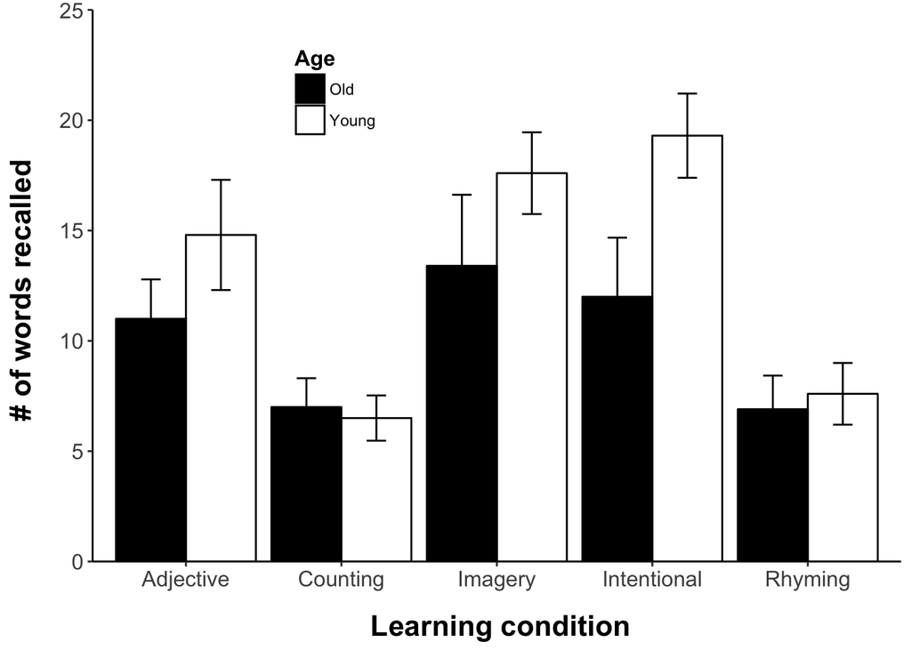

```r
p + theme_classic() + theme(
    # tweaking lineheight
    axis.title = element_text(size = 16, face = "bold", lineheight = .55),
    axis.text = element_text(size = 12),
    legend.title = element_text(size = 12, face = "bold"),
    legend.position = c(.3,.85)) +
  scale_fill_manual(values=c("black","white")) +
  scale_y_continuous(expand = c(0,0)) + expand_limits(y=c(0,25)) +

  # specific axis titles
  xlab("\n Learning condition") +
  ylab ("# of words recalled \n")
```

Finally, we may want to add a bit of a buffer (white space) around the plot:

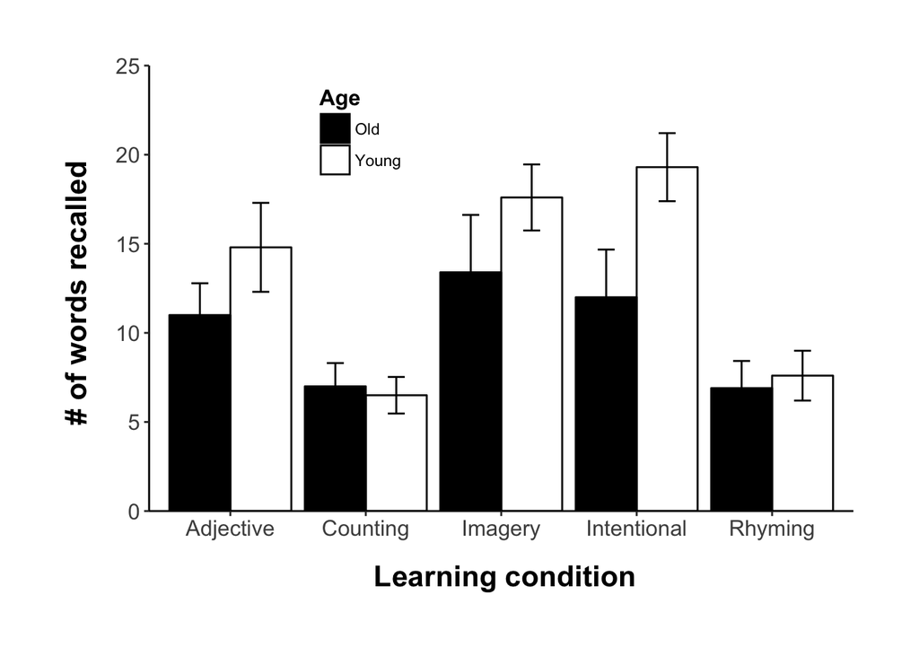

```r
p + theme_classic() + theme(
    axis.title = element_text(size = 16, face = "bold", lineheight = .55),
    axis.text = element_text(size = 12),
    legend.title = element_text(size = 12, face = "bold"),
    legend.position = c(.3,.85)) +
  scale_fill_manual(values=c("black","white")) +
  scale_y_continuous(expand = c(0,0)) + expand_limits(y=c(0,25)) +
  xlab("\n Learning condition") +
  ylab ("# of words recalled \n") +

  # adding .5 inch plot margins to (top, right, bottom, left)
  # feel free to adjust accordingly
  theme(plot.margin=unit(c(.5,.5,.5,.5),"in"))
```

Keep in mind that you may need to adjust each of these values according to your own preferences. In particular, you may have to tweak the font size to be just right for the size of plot you intend to print.

## Line plot example

Let’s say I want to do a line plot and in addition to having group represented by different line types and shapes, I also want different colors. As a reminder, here was our base lineplot:

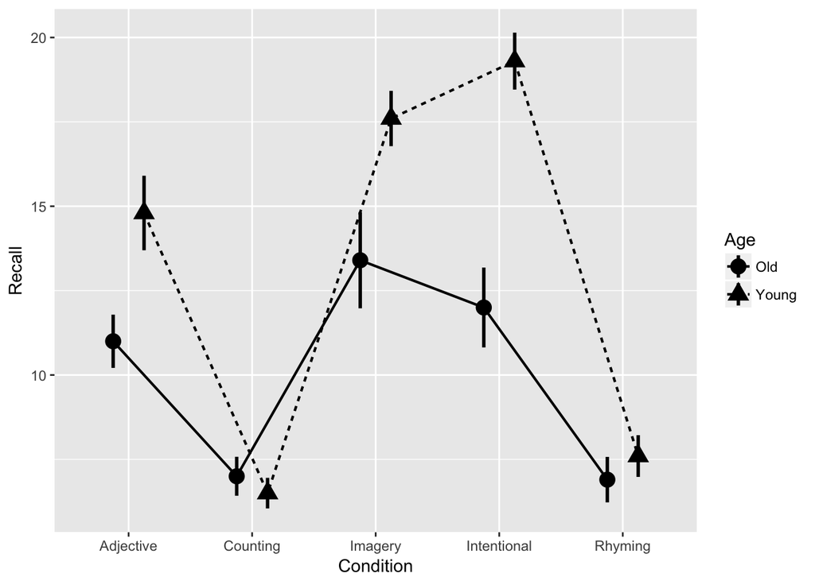

```r
p <- ggplot(data=dataset,mapping = aes(x=Condition,y=Recall,group=Age)) +
  stat_summary(fun.data = mean_se, size=1, color="black", geom="pointrange", position = position_dodge(.5), aes(shape=Age)) +
  # adding aes() changing linetype
  stat_summary(fun.y = mean, size=0.75, color="black", geom="line", position = position_dodge(.5), aes(linetype=Age))
show(p)
```

And here is code to generate plots that are APA friendly with my additional goal of adding a second line color. First I need to re-adjust my baseline to include `color=Age` differentiation. Note that I also need to get rid of my explicit call for color to be black (the `color=“black” made outside of aes)

```r
p <- ggplot(data=dataset,mapping = aes(x=Condition,y=Recall,group=Age)) +
  # update to made color change with age
  stat_summary(fun.data = mean_se, size=1, geom="pointrange", position = position_dodge(.5), aes(shape=Age, color=Age)) +
  # updated to made color change with age
  stat_summary(fun.y = mean, size=0.75, geom="line", position = position_dodge(.5), aes(linetype=Age, color=Age))
```

And not to APA-ify. Note that I’m using `scale_color_manual()` instead of `scale_fill_mamua()l`; remember that `color` refers to lines, while `fill` refers to enclosed areas. Also, I’m using “black” and “darkgrey”:

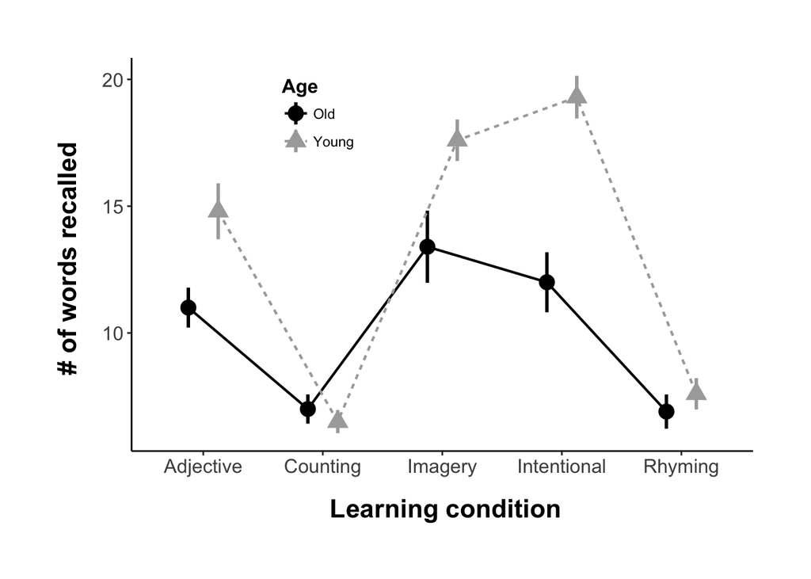

```r
p + theme_classic() + theme(
    axis.title = element_text(size = 16, face = "bold", lineheight = .55),
    axis.text = element_text(size = 12),
    legend.title = element_text(size = 12, face = "bold"),
    legend.position = c(.3,.85)) +
  scale_color_manual(values=c("black","darkgrey")) +
  xlab("\n Learning condition") +
  ylab ("# of words recalled \n") +
  theme(plot.margin=unit(c(.5,.5,.5,.5),"in"))
```

## Boxplot example

Finally, lets call back to our baseline boxplot. Note our baseline already has color assigned to `Age`:

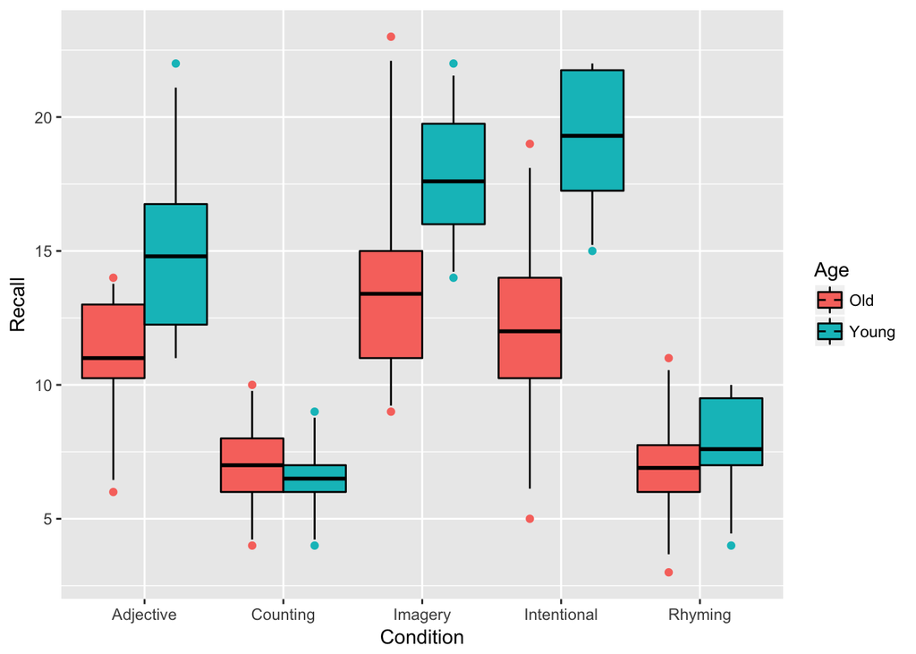

```r
p <- ggplot(data=dataset,mapping = aes(x=Condition,y=Recall,group=Age)) +
  # calling geom="baxplot"; using position to set grouped plots side-by-side
  stat_summary(fun.data = box_mean, size=.5, color="black", geom="boxplot", position=position_dodge(.9), aes(fill=Age)) +
  stat_summary(fun.y = box_out, geom="point", position=position_dodge(width=.9), aes(color=Age))
show(p)
```

Back to using `scale_fill_manual()` for the IQR areas. Using `scale_color_manual` for the outlier points. Using “grey50” and “grey80”:

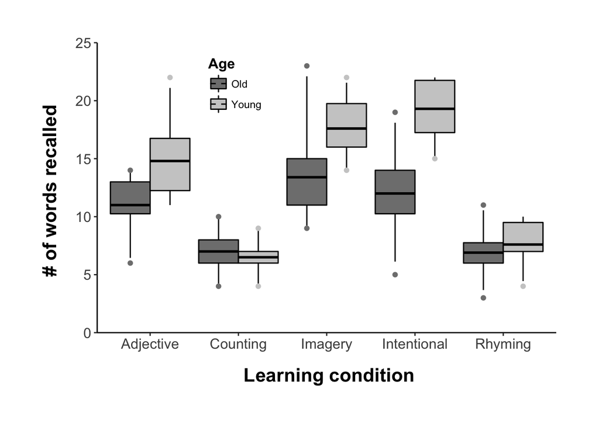

```r
p + theme_classic() + theme(
    axis.title = element_text(size = 16, face = "bold", lineheight = .55),
    axis.text = element_text(size = 12),
    legend.title = element_text(size = 12, face = "bold"),
    legend.position = c(.3,.85)) +

  #boxplot colors for areas and points
  scale_fill_manual(values=c("grey50","grey80")) +
  scale_color_manual(values=c("grey50","grey80")) +

  scale_y_continuous(expand = c(0,0)) + expand_limits(y=c(0,25)) +
  xlab("\n Learning condition") +
  ylab ("# of words recalled \n") +
  theme(plot.margin=unit(c(.5,.5,.5,.5),"in"))
```

# APA figures (`cowplot` method)

The method in the previous section only relies on you having `ggplot2` installed. Not other packages are necessary. However, if you have `cowplot` [link](https://cran.r-project.org/web/packages/cowplot/vignettes/introduction.html) installed (remember that cowplot may be used to `plot_grid()` multiple plots together) you may also call on `theme_cowplot()` which blanks out your background, adds axis lines, and changes your font-size. Let’s load cowplot and apply `theme_cowplot()` instead of the modifications we made above:

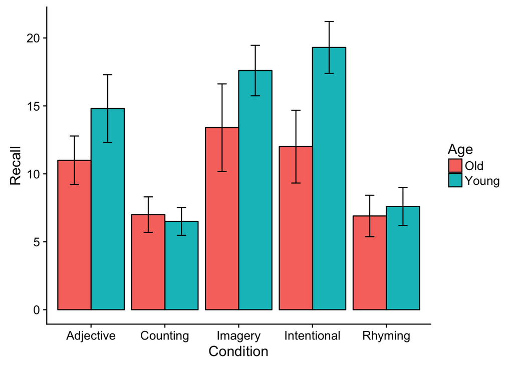

```r
# check to see if cowplot is installed, if not then install and load:
if(!require(cowplot)){install.packages("cowplot")}; require(cowplot)
# creating boriginal barplot:
p <- ggplot(data=dataset,mapping = aes(x=Condition,y=Recall,group=Age)) +
  # calling geom="bar" where top of bar is the mean; note that size and color here refer to bar's perimeter lines.
  stat_summary(fun.y = mean, size=.5, color="black", geom="bar", position = position_dodge(.9), aes(fill=Age)) +
  # adding 95% CI error bars:
  stat_summary(fun.data = mean_cl_normal, size=.5, width= 0.25, color="black", geom="errorbar", position = position_dodge(.9))

p + theme_cowplot()
```

From here we can made any additional adjustments we like (as above):

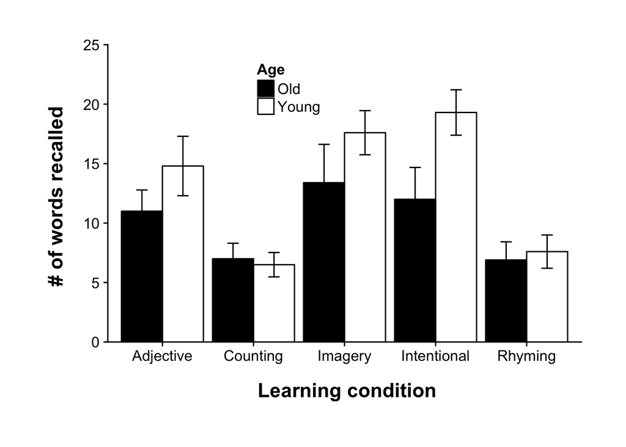

```r
p + theme_cowplot() + theme(
    axis.title = element_text(size = 16, face = "bold", lineheight = .55),
    axis.text = element_text(size = 12),
    legend.title = element_text(size = 12, face = "bold"),
    legend.position = c(.3,.85)) +
  scale_fill_manual(values=c("black","white")) +
  scale_y_continuous(expand = c(0,0)) + expand_limits(y=c(0,25)) +
  xlab("\n Learning condition") +
  ylab ("# of words recalled \n") +

  # adding .5 inch plot margins to (top, right, bottom, left)
  # feel free to adjust accordingly
  theme(plot.margin=unit(c(.5,.5,.5,.5),"in"))
```

# APA figures (`ggthemr` method)

Coming soon (although you’ve seen it before)